# Session 5 — Spatial Regression and Reporting

Residual autocorrelation · LM tests · spatial lag and error models · impacts · reporting · Lab 5

Community Medicine Workshop

## Where we are

- Sessions 3–4: the outcome is spatially clustered, and we know where
- Today: **regression on areas**. The usual assumption of **independent residuals** often fails
- By the end you can:
  - test regression **residuals** for spatial autocorrelation
  - use **Lagrange multiplier tests** to choose lag or error
  - fit and compare **spatial lag** and **spatial error** models
  - **report** a spatial analysis

# Topic 1 — Check the residuals

## Fit OLS first

```r
ols <- lm(dengue_per_100k ~ poverty_index + literacy_pct, data = blocks)
round(summary(ols)$coefficients, 3)
```

```
              Estimate Std. Error t value Pr(>|t|)
(Intercept)   -101.067     61.802  -1.635    0.106
poverty_index    1.445      0.335   4.306    0.000
literacy_pct     0.981      0.603   1.629    0.107
```

## Moran’s I on the residuals

```r
lm.morantest(ols, lw, zero.policy = TRUE)
```

```
    Global Moran I for regression residuals

data:
model: lm(formula = dengue_per_100k ~ poverty_index + literacy_pct,
data = blocks)
weights: lw

Moran I statistic standard deviate = 4.4335, p-value = 4.635e-06
alternative hypothesis: greater
sample estimates:
Observed Moran I      Expectation         Variance
     0.273945405     -0.023128244      0.004489825
```

A significant **positive** residual Moran’s I means the model leaves spatial structure unexplained: **independence fails** and standard errors are probably **too small**.

```r
blocks$res_ols <- residuals(ols)
ggplot(blocks) + geom_sf(aes(fill = res_ols)) + scale_fill_gradient2(low = "#2166ac", mid = "white", high = "#b2182b", name = "Residual") +
  labs(title = "OLS residuals: neighbours share the same sign")
```

## Moran’s I on the residuals

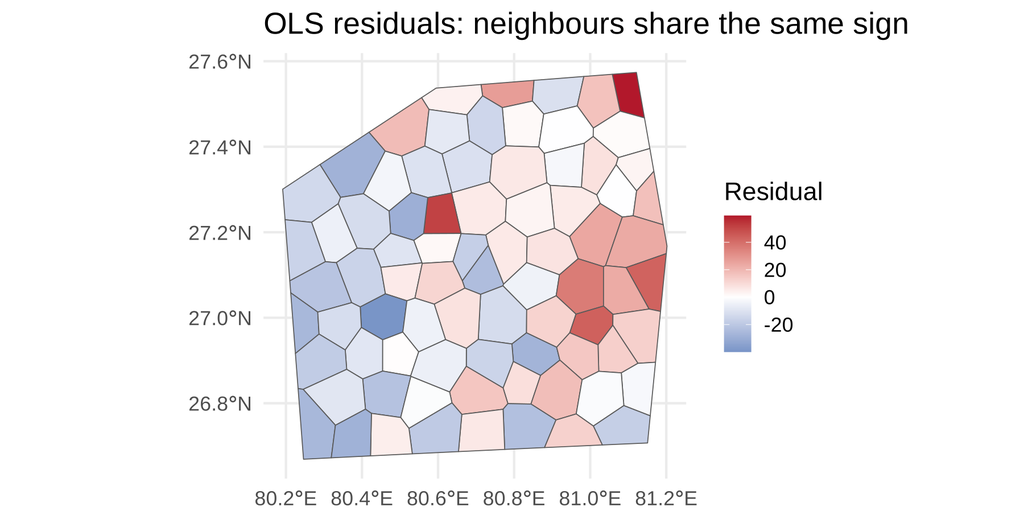

# Topic 2 — Which spatial model?

## Two structures

| Model | Idea | Think of |
| --- | --- | --- |
| **Spatial lag (SAR)** | my outcome depends on my **neighbours’ outcomes** | contagion, spillover |
| **Spatial error (SEM)** | **omitted shared factors** make neighbouring errors alike | unmeasured exposures |

Lag: y = ρWy + Xβ + ε | Error: y = Xβ + u, u = λWu + ε

## Lagrange multiplier tests

```r
lm.RStests(ols, lw, test = c("RSerr", "RSlag", "adjRSerr", "adjRSlag"), zero.policy = TRUE)
```

## Lagrange multiplier tests

```
    Rao's score (a.k.a Lagrange multiplier) diagnostics for spatial
    dependence

data:
model: lm(formula = dengue_per_100k ~ poverty_index + literacy_pct,
data = blocks)
test weights: lw

RSerr = 14.895, df = 1, p-value = 0.0001137


    Rao's score (a.k.a Lagrange multiplier) diagnostics for spatial
    dependence

data:
model: lm(formula = dengue_per_100k ~ poverty_index + literacy_pct,
data = blocks)
test weights: lw

RSlag = 19.289, df = 1, p-value = 1.124e-05


    Rao's score (a.k.a Lagrange multiplier) diagnostics for spatial
    dependence

data:
model: lm(formula = dengue_per_100k ~ poverty_index + literacy_pct,
data = blocks)
test weights: lw

adjRSerr = 0.15191, df = 1, p-value = 0.6967


    Rao's score (a.k.a Lagrange multiplier) diagnostics for spatial
    dependence

data:
model: lm(formula = dengue_per_100k ~ poverty_index + literacy_pct,
data = blocks)
test weights: lw

adjRSlag = 4.5459, df = 1, p-value = 0.033
```

## Choosing from the LM tests

- If **only one** plain test is significant, use that model
- If **both** are, prefer the model whose **robust** test (`adjRSerr` or `adjRSlag`) is larger and significant
- Use **theory** too: contagion points to lag, omitted exposures to error

## Fit and compare

```r
sem <- errorsarlm(dengue_per_100k ~ poverty_index + literacy_pct, data = blocks, listw = lw, zero.policy = TRUE)
sar <- lagsarlm(dengue_per_100k ~ poverty_index + literacy_pct, data = blocks, listw = lw, zero.policy = TRUE)
c(lambda = sem$lambda, rho = sar$rho) |> round(3)
```

```
lambda.lambda       rho.rho
        0.535         0.515
```

```r
AIC(ols, sem, sar)
```

```
    df      AIC
ols  4 698.4286
sem  5 687.2759
sar  5 684.6838
```

```r
c(OLS = unname(moran.test(residuals(ols), lw, zero.policy = TRUE)$estimate[1]), SEM = unname(moran.test(residuals(sem), lw, zero.policy = TRUE)$estimate[1])) |> round(3)
```

```
   OLS    SEM
 0.274 -0.042
```

Lower AIC is better (same data). The residual Moran’s I should fall towards 0.

# Topic 3 — Interpreting and reporting

## Coefficients in the lag model

In a **lag** model a change in one block’s poverty also changes its neighbours’ rates, which feed back. The coefficient is **not** the whole effect. Report **impacts**: direct, indirect and total.

```r
set.seed(6)
summary(impacts(sar, listw = lw, R = 199), zstats = TRUE, short = TRUE)
```

```
Impact measures (lag, exact):
                       Direct  Indirect    Total
poverty_index dy/dx 0.9339023 0.8647157 1.798618
literacy_pct dy/dx  0.8134276 0.7531661 1.566594
========================================================
Simulation results ( variance matrix):
========================================================
Simulated standard errors
                       Direct  Indirect     Total
poverty_index dy/dx 0.3400153 0.5790857 0.7998079
literacy_pct dy/dx  0.6010227 0.8975023 1.4072140

Simulated z-values:
                      Direct  Indirect    Total
poverty_index dy/dx 2.715598 1.5611009 2.284744
literacy_pct dy/dx  1.332292 0.9089538 1.148742

Simulated p-values:
                    Direct    Indirect Total
poverty_index dy/dx 0.0066156 0.11850  0.022328
literacy_pct dy/dx  0.1827641 0.36337  0.250662
```

In the **error** model the coefficients keep the OLS meaning, with corrected standard errors.

## Other routes

- **Add covariates** that explain the clustering; the residual autocorrelation may vanish
- **Count data with unequal populations**: Poisson models with a spatial random effect (CAR / BYM in `INLA`, `brms`)
- **Geographically weighted regression** lets coefficients vary over space
- Always **map the residuals**

## Reporting checklist

1. The **outcome** (rate, not count) and the **areas**, with the **CRS** if distances were used
2. The **weights**: definition, standardisation, isolates
3. **Global** result: Moran’s I, p-value type, simulations
4. **Local** results: method, adjustment, map; say they are exploratory
5. **Regression**: residual Moran’s I, LM tests, model chosen and why, parameter (`rho` or `lambda`), AIC vs OLS, impacts for a lag model
6. **Limitations**: area size (MAUP), small numbers, edge effects, association not cause

## 🔧 Switch to R — Lab 5

**File:** `gis-workshop/labs/lab5_regression.R`

- `lm()` then `lm.morantest()` · map the residuals
- `lm.RStests()` · `errorsarlm()` · `lagsarlm()` · `AIC()`
- `impacts()` for the lag model

**Time:** 40 minutes · answer the Q questions in the comments

## Self-check quiz (1/5)

Residuals of an area-level regression have a significant positive Moran’s I. What is the main consequence?

- The regression coefficients become zero in each of the fitted models
- The model must be refitted using fewer of the areas in the data
- Standard errors are probably too small, so p-values are optimistic
- The outcome variable is spatially random and so should be dropped

## Self-check quiz (2/5)

Which situation points to a spatial LAG model?

- An unmeasured exposure affects blocks that lie next to each other
- The outcome in an area influences its neighbours’ outcomes (contagion)
- The residuals are normally distributed with a constant variance throughout
- The covariates are strongly correlated with each other and with the outcome

## Self-check quiz (3/5)

Both plain LM tests are significant, but only the robust lag test is. What do you conclude?

- A spatial error model is the better candidate
- Neither model is needed, so ordinary regression is fine
- A spatial lag model is the better candidate
- The tests are contradictory, so they should be ignored

## Self-check quiz (4/5)

In a spatial lag model, why is the coefficient of a covariate not its full effect?

- The coefficient is divided by the number of areas in the study
- Lag models estimate the effects for the neighbours, not for the area
- The coefficient is measured on a different scale from the outcome
- A change in one area also changes its neighbours’ outcomes

## Self-check quiz (5/5)

After fitting a spatial error model, what should you check?

- The residual Moran’s I, which should now be close to 0
- Whether the number of blocks has doubled during fitting
- That each covariate has become significant at the 5% level
- Whether the lambda value has become equal to 1

## Score and take-home

**Your score:**

- **Always test residuals** of an area-level regression (`lm.morantest`)
- **LM tests** (and robust versions) suggest lag or error; theory should agree
- Report **rho / lambda**, AIC vs OLS, the residual check; use **impacts** for lag
- For counts with unequal populations, consider **Poisson models with spatial random effects**

**Next:** Back to the cheat sheet and the **Dungeons & Dataframes** GIS world (coming)